# Supplementary Materials: Customising Visualisations

## Supplementary Materials: Customising Visualisations

Optional examples to explore in your own time, alongside the Week 5 theme exercise, `03_themes.Rmd`.

- Use the exercise to compare themes and practise changing individual elements.
- Use these slides as worked examples for facet labels, axis text, legends, grids, backgrounds, and facet strips.
- Choose changes that improve readability or comparison; you do not need to try every option.

These materials extend the main Week 5 session; detailed theme customisation is not required during class.

## Facet Strips Are Labels Too

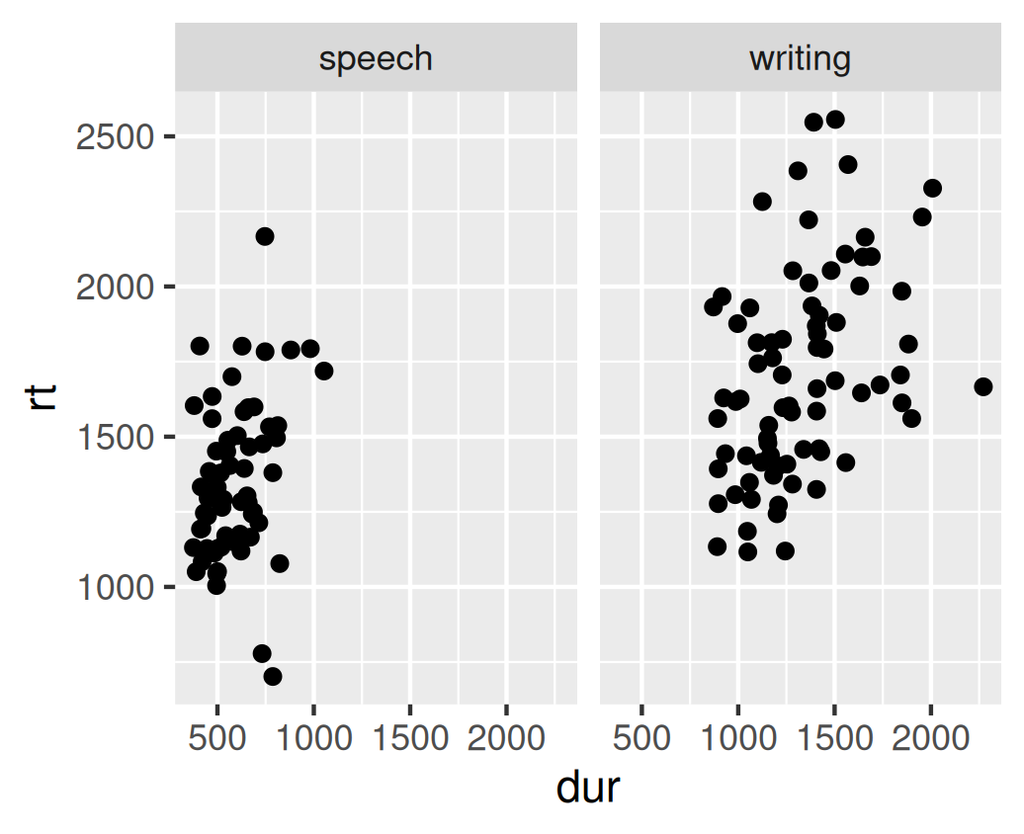

```r
ggplot(d_spellname,
       aes(y = rt,
           x = dur)) +
  geom_point() +
  facet_grid(~modality)
```

## Facet Labels Can Come From The Data

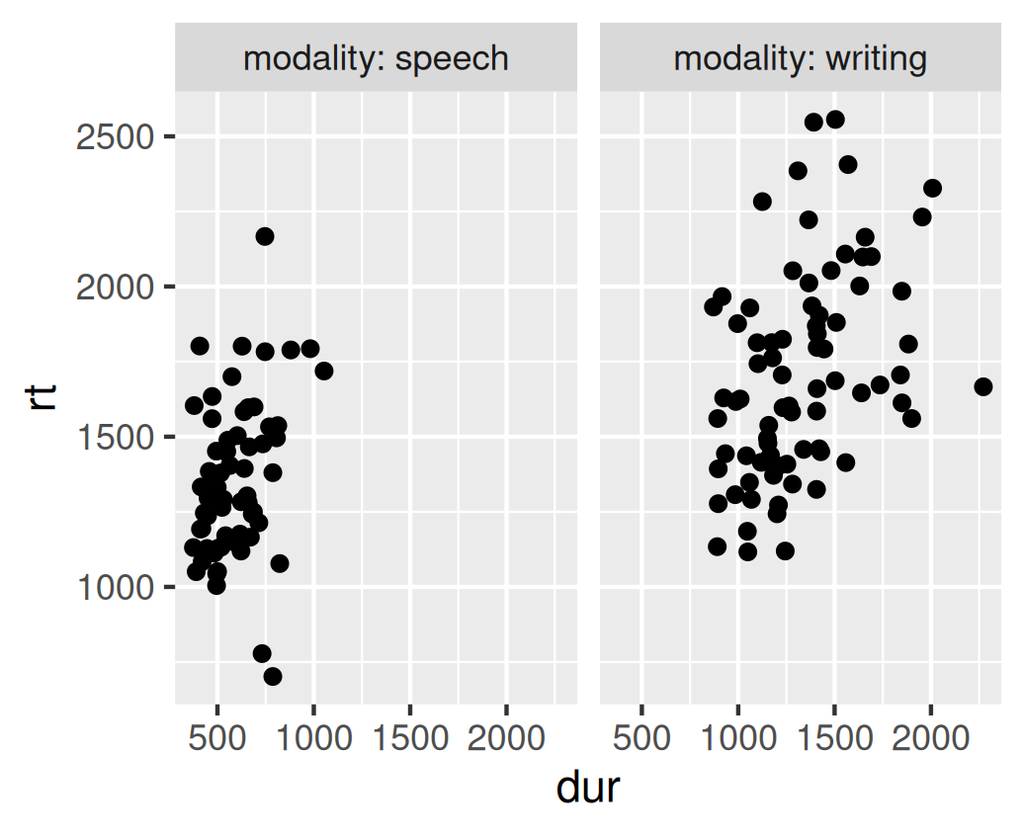

```r
ggplot(d_spellname,
       aes(y = rt,
           x = dur)) +
  geom_point() +
  facet_grid(~modality,
             labeller = label_both)
```

## Recoding Changes The Data Labels

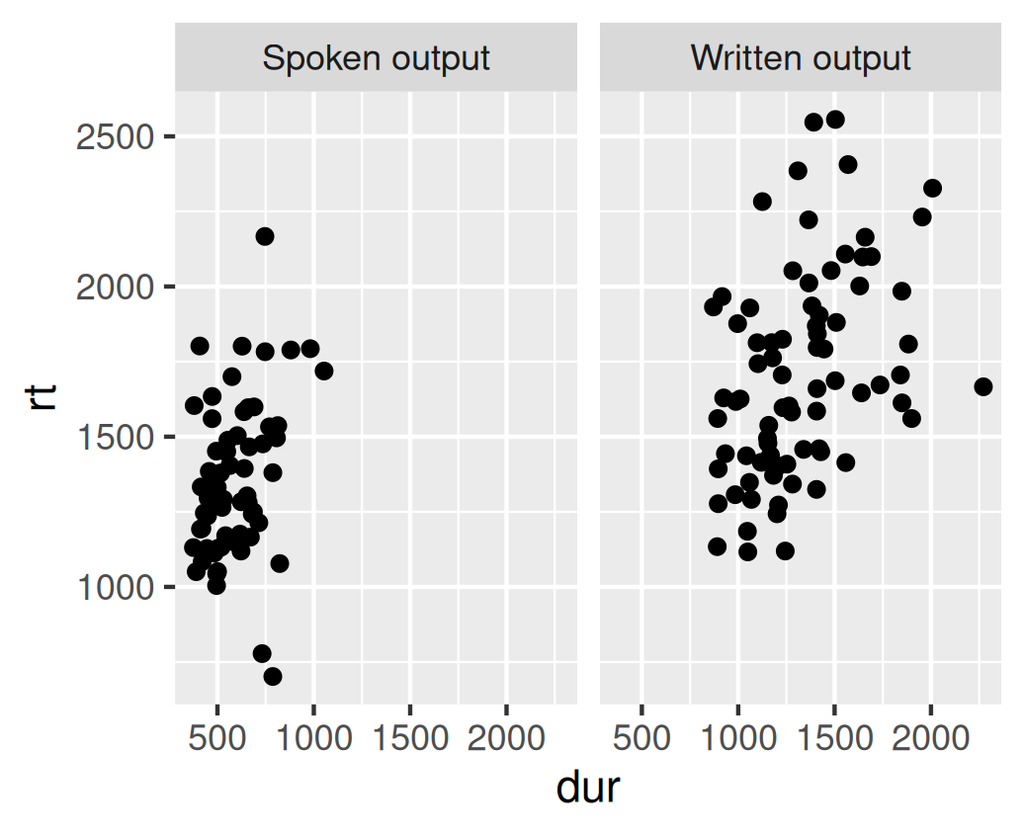

```r
d_spellname <- mutate(d_spellname,
  modality = recode(modality,
    speech = "Spoken output",
    writing = "Written output"))

ggplot(d_spellname,
       aes(x = dur,
           y = rt)) +
  geom_point() +
  facet_grid(~modality)
```

## Strip Labels Should Match The Story

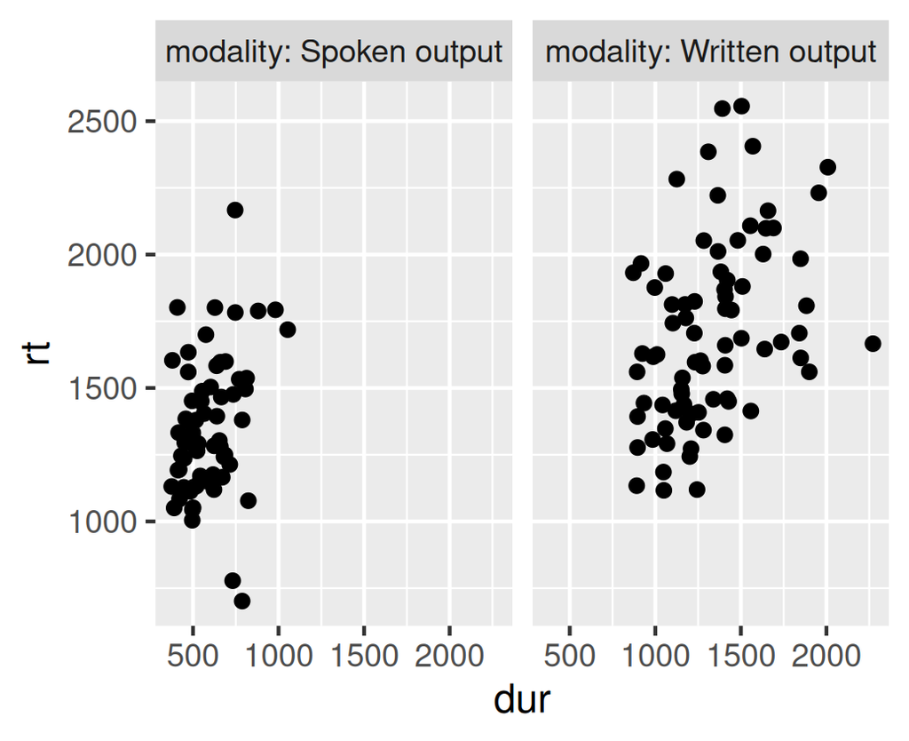

```r
ggplot(d_spellname,
       aes(y = rt,
           x = dur)) +
  geom_point() +
  facet_grid(~modality, labeller = label_both)
```

## Start From The `ggplot2` Default

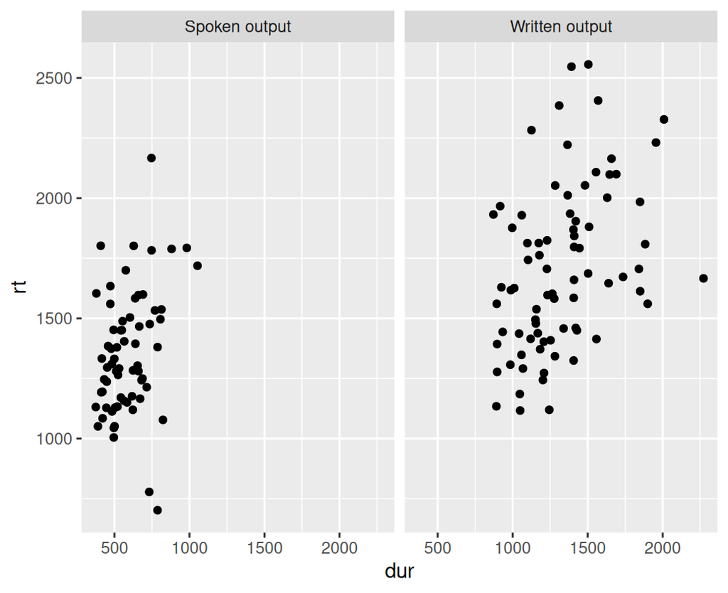

```r
ggplot(d_spellname,
       aes(y = rt,
           x = dur)) +
  geom_point() +
  facet_grid(~modality) +
  theme_grey(base_size = 11)
```

## `theme_minimal()`: No Panel Background

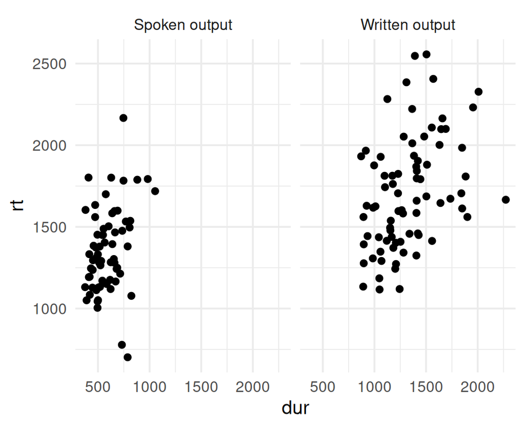

```r
ggplot(d_spellname,
       aes(y = rt,
           x = dur)) +
  geom_point() +
  facet_grid(~modality) +
  theme_minimal(base_size = 14)
```

## `theme_light()`: Light Grid And Border

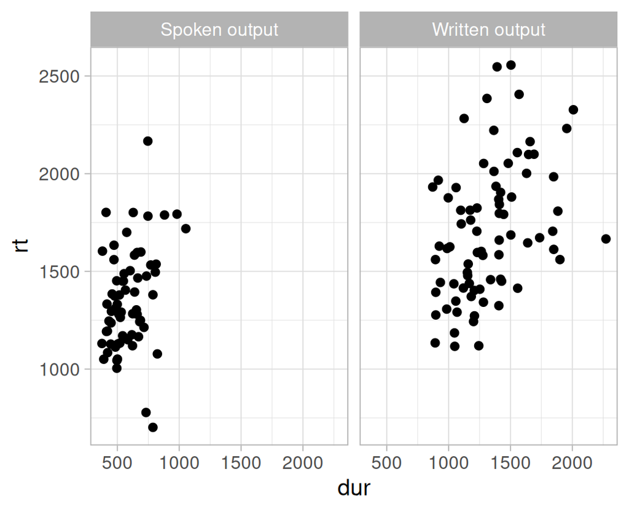

```r
ggplot(d_spellname,
       aes(y = rt,
           x = dur)) +
  geom_point() +
  facet_grid(~modality) +
  theme_light(base_size = 14)
```

## `theme_dark()`: A Dark Panel Background

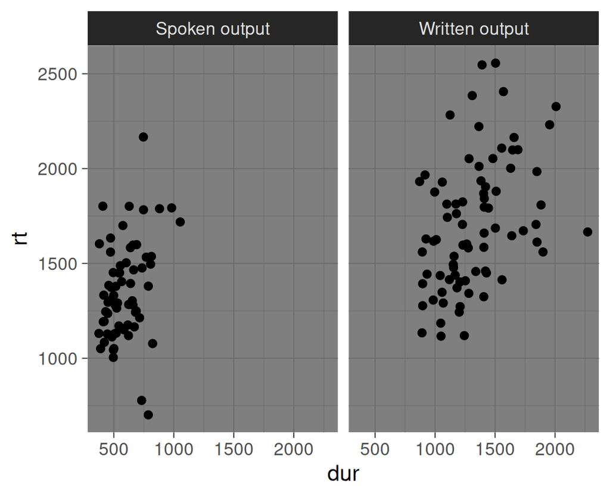

```r
ggplot(d_spellname,
       aes(y = rt,
           x = dur)) +
  geom_point() +
  facet_grid(~modality) +
  theme_dark(base_size = 14)
```

## Theme Packages Add Starting Points

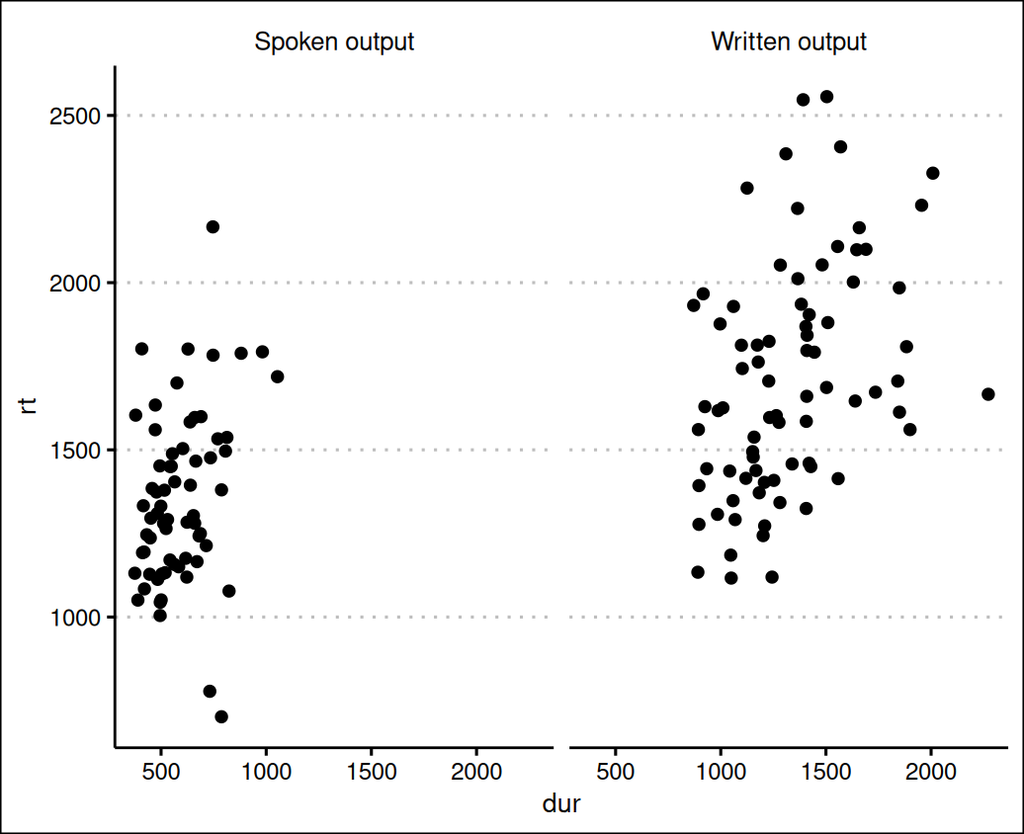

```r
ggplot(d_spellname,
       aes(y = rt,
           x = dur)) +
  geom_point() +
  facet_grid(~modality) +
  theme_clean()
```

## Choose Themes For The Comparison

- `axis`
- `legend`
- `panel`
- `plot`
- `strip`

```r
ggplot(d_spellname,
       aes(y = rt,
           x = dur)) +
  geom_point() +
  theme()
```

## Axis Text Is Part Of Readability

- `axis.text`
  - `axis.text.x`
  - `axis.text.y`
- `axis.title`
  - `axis.title.x`
  - `axis.title.y`

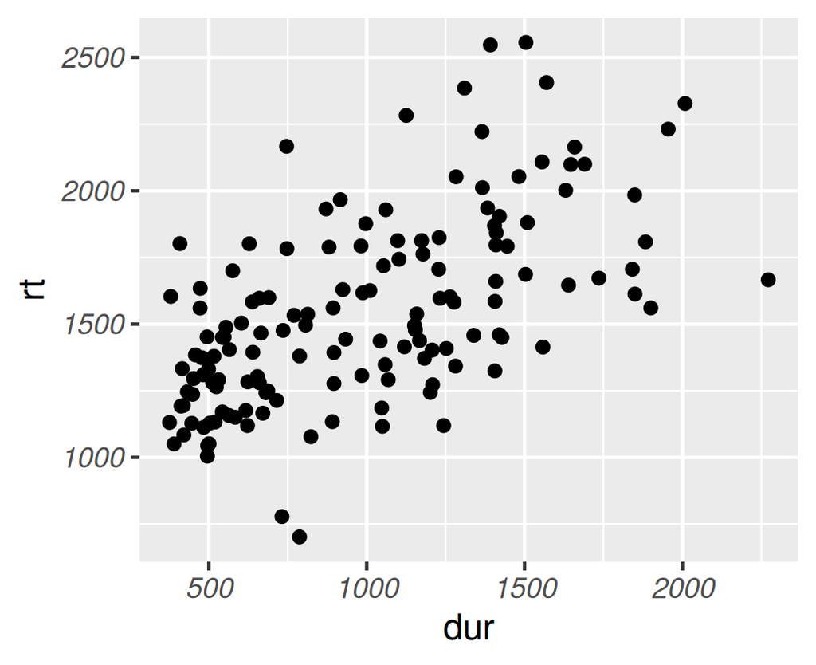

```r
ggplot(d_spellname,
       aes(y = rt,
           x = dur)) +
  geom_point() +
  theme(axis.text =
          element_text(face = "italic"))
```

## Bold Axis Titles Can Add Emphasis

- `axis.text`
  - `axis.text.x`
  - `axis.text.y`
- `axis.title`
  - `axis.title.x`
  - `axis.title.y`

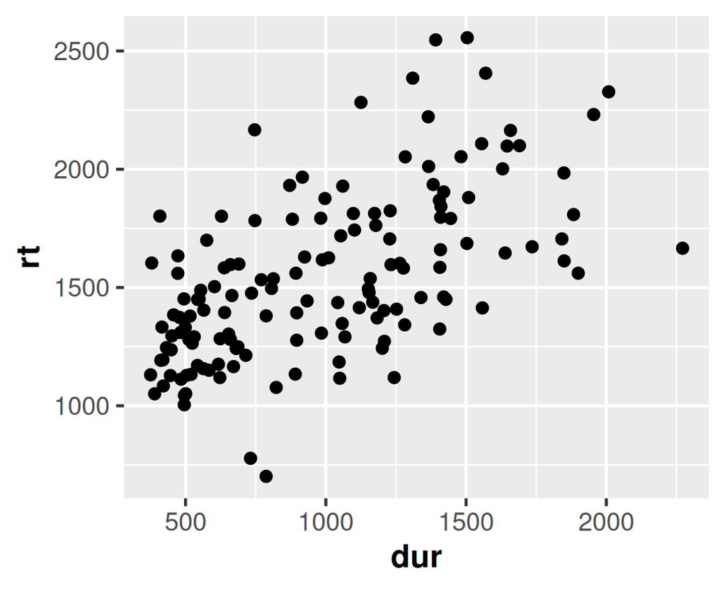

```r
ggplot(d_spellname, aes(y = rt,
    x = dur)) +
  geom_point() +
  theme(axis.title =
          element_text(face = "bold"))
```

## Axis Titles And Tick Labels Are Separate

- `axis.text`
  - `axis.text.x`
  - `axis.text.y`
- `axis.title`
  - `axis.title.x`
  - `axis.title.y`

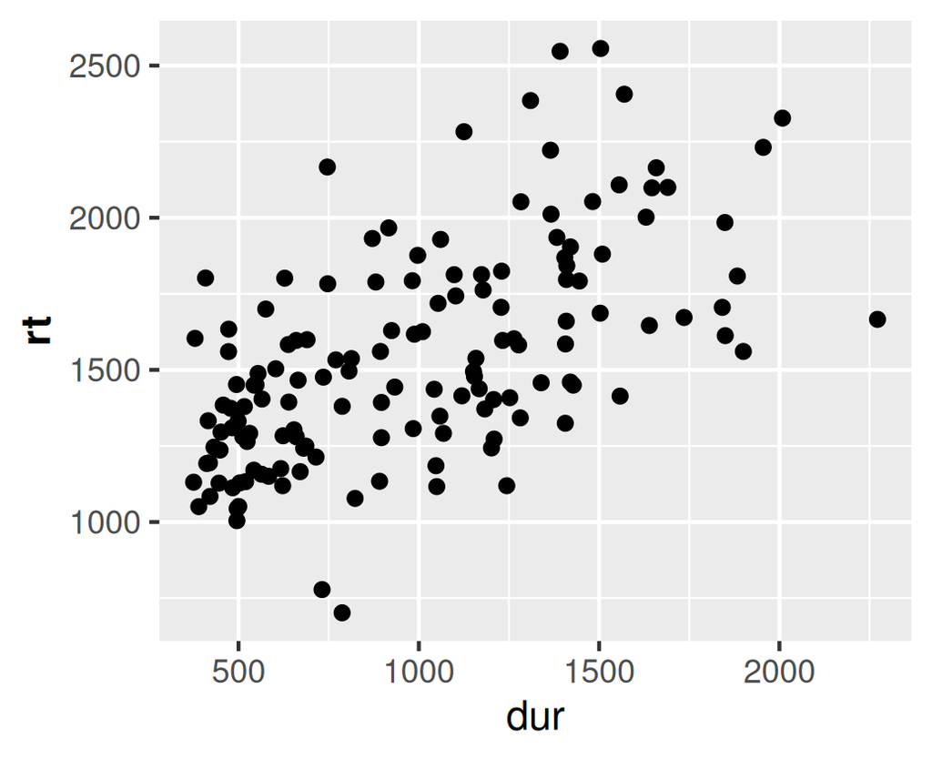

```r
ggplot(d_spellname, aes(y = rt,
    x = dur)) +
  geom_point() +
  theme(axis.title.y =
          element_text(face = "bold"))
```

## Legends Compete For Plot Space

- `legend.background`
- `legend.margin`
- `legend.spacing`
- `legend.key`
- `legend.text`
- `legend.title`
- `legend.position`
- `legend.orientation`
- `legend.justification`
- `legend.box`

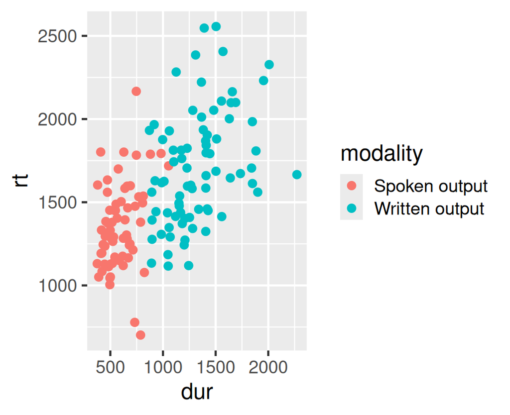

```r
ggplot(d_spellname, aes(y = rt,
    x = dur,
    colour = modality)) +
  geom_point() +
  theme()
```

## Move Legends When Space Is Tight

- `legend.background`
- `legend.margin`
- `legend.spacing`
- `legend.key`
- `legend.text`
- `legend.title`
- `legend.position`
- `legend.orientation`
- `legend.justification`
- `legend.box`

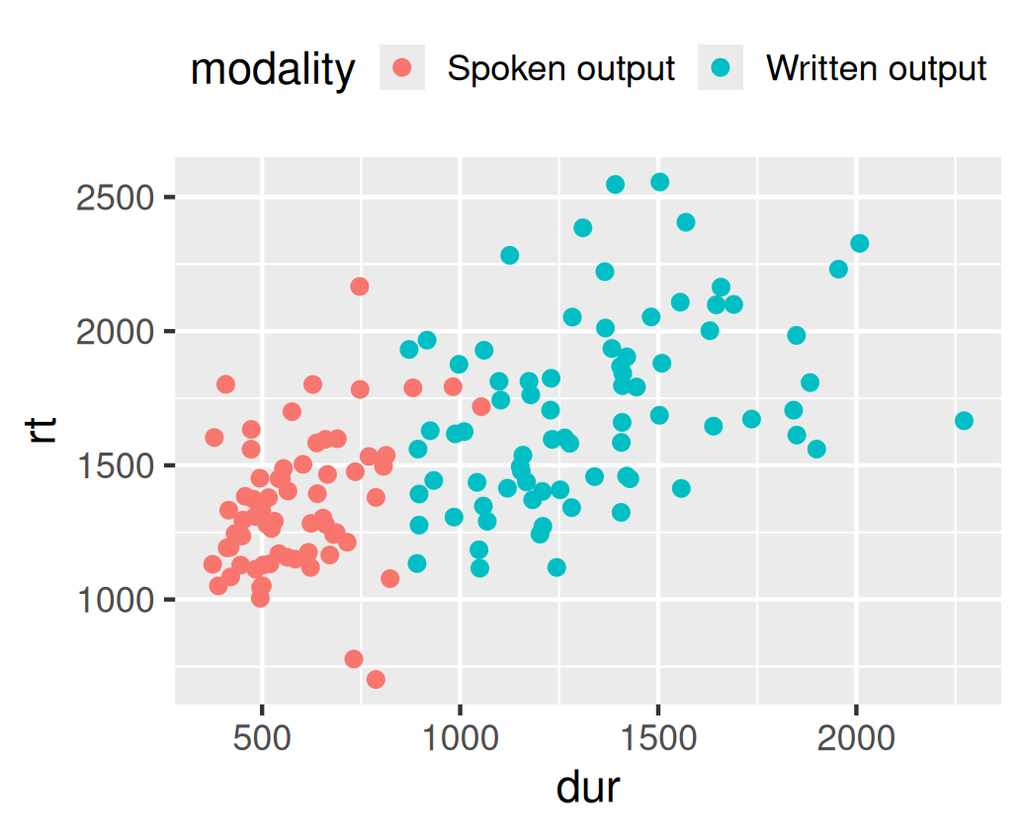

```r
ggplot(d_spellname, aes(y = rt,
    x = dur,
    colour = modality)) +
  geom_point() +
  theme(legend.position = "top")
```

## Align A Top Legend To The Right

- `legend.background`
- `legend.margin`
- `legend.spacing`
- `legend.key`
- `legend.text`
- `legend.title`
- `legend.position`
- `legend.orientation`
- `legend.justification`
- `legend.box`

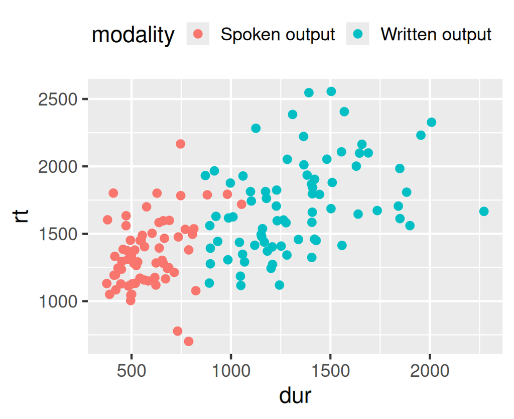

```r
ggplot(d_spellname, aes(y = rt,
    x = dur,
    colour = modality)) +
  geom_point() +
  theme(legend.position = "top",
        legend.justification = "right")
```

## An Inside Legend Can Cover Data

- `legend.background`
- `legend.margin`
- `legend.spacing`
- `legend.key`
- `legend.text`
- `legend.title`
- `legend.position`
- `legend.orientation`
- `legend.justification`
- `legend.box`

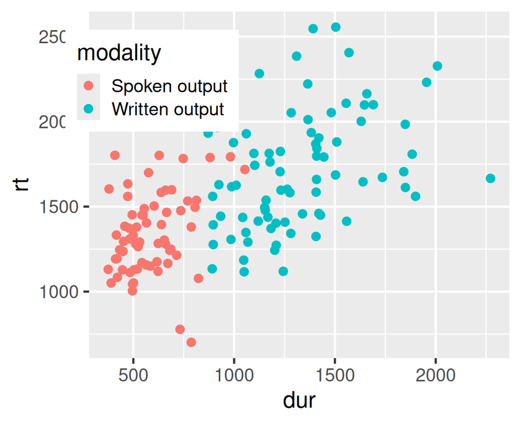

```r
ggplot(d_spellname, aes(y = rt,
    x = dur,
    colour = modality)) +
  geom_point() +
  theme(legend.position = c(.15, .8))
```

## Grid Lines Can Help Or Distract

- `panel.background`
- `panel.border`
- `panel.spacing`
- `panel.grid`
  - `panel.grid.major`
  - `panel.grid.minor`

```r
ggplot(d_spellname, aes(y = rt,
    x = dur)) +
  geom_point() +
  theme()
```

## Remove The Panel Background

- `panel.background`
- `panel.border`
- `panel.spacing`
- `panel.grid`
  - `panel.grid.major`
  - `panel.grid.minor`

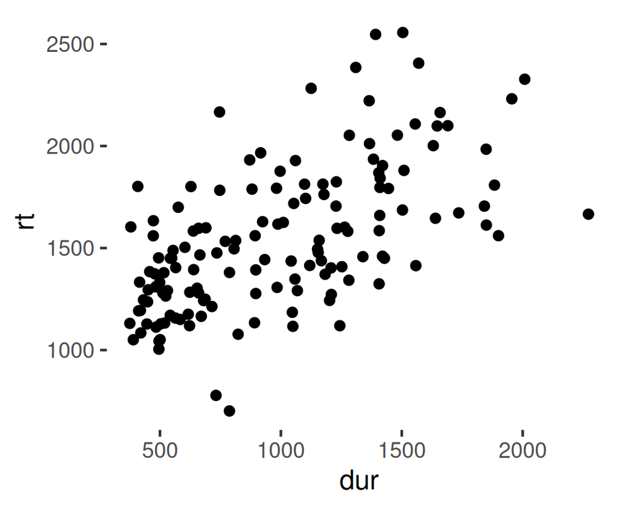

```r
ggplot(d_spellname, aes(y = rt,
    x = dur)) +
  geom_point() +
  theme(panel.background =
        element_blank())
```

## Plot Properties Control The Whole Figure

- `plot.background`
- `plot.margin`
- `plot.title`
- `plot.subtitle`
- `plot.caption`
- `plot.tag`

```r
ggplot(d_spellname, aes(y = rt,
    x = dur)) +
  geom_point() +
  theme()
```

## A Coloured Plot Background Adds Non-Data Ink

- `plot.background`
- `plot.margin`
- `plot.title`
- `plot.subtitle`
- `plot.caption`
- `plot.tag`

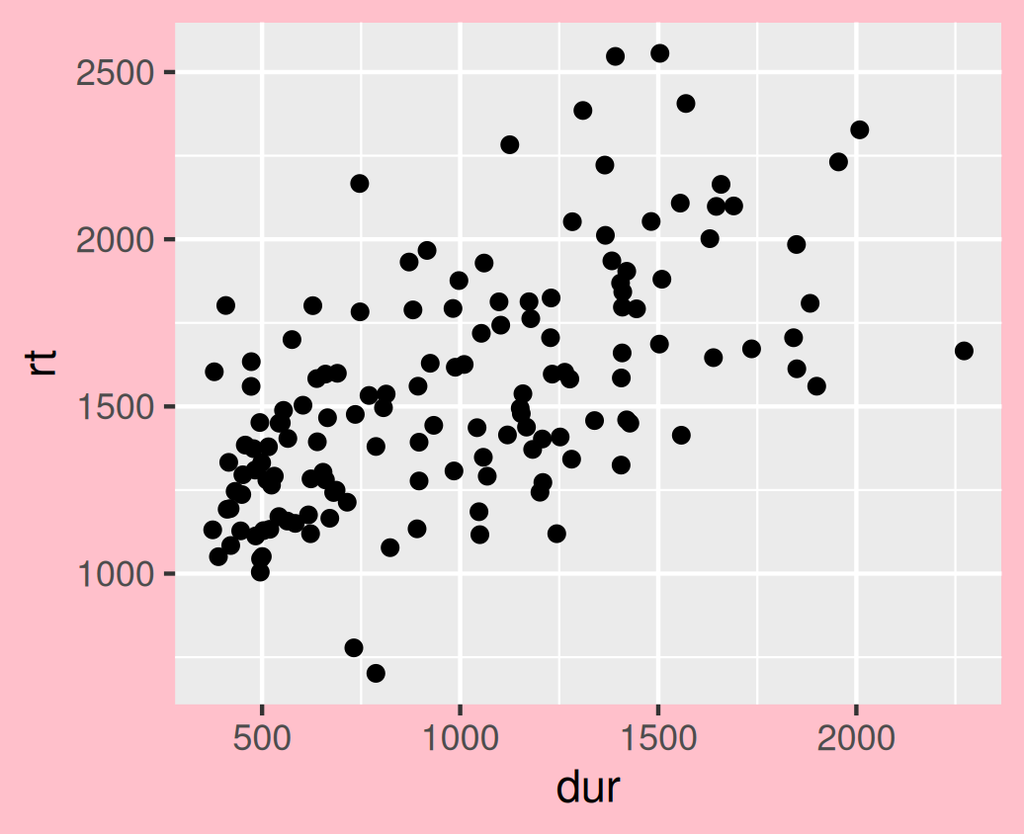

```r
ggplot(d_spellname, aes(y = rt,
    x = dur)) +
  geom_point() +
  theme(plot.background = element_rect(
    fill = "pink"))
```

## Plot Margins Affect Readability

- `plot.background`
- `plot.margin`
- `plot.title`
- `plot.subtitle`
- `plot.caption`
- `plot.tag`

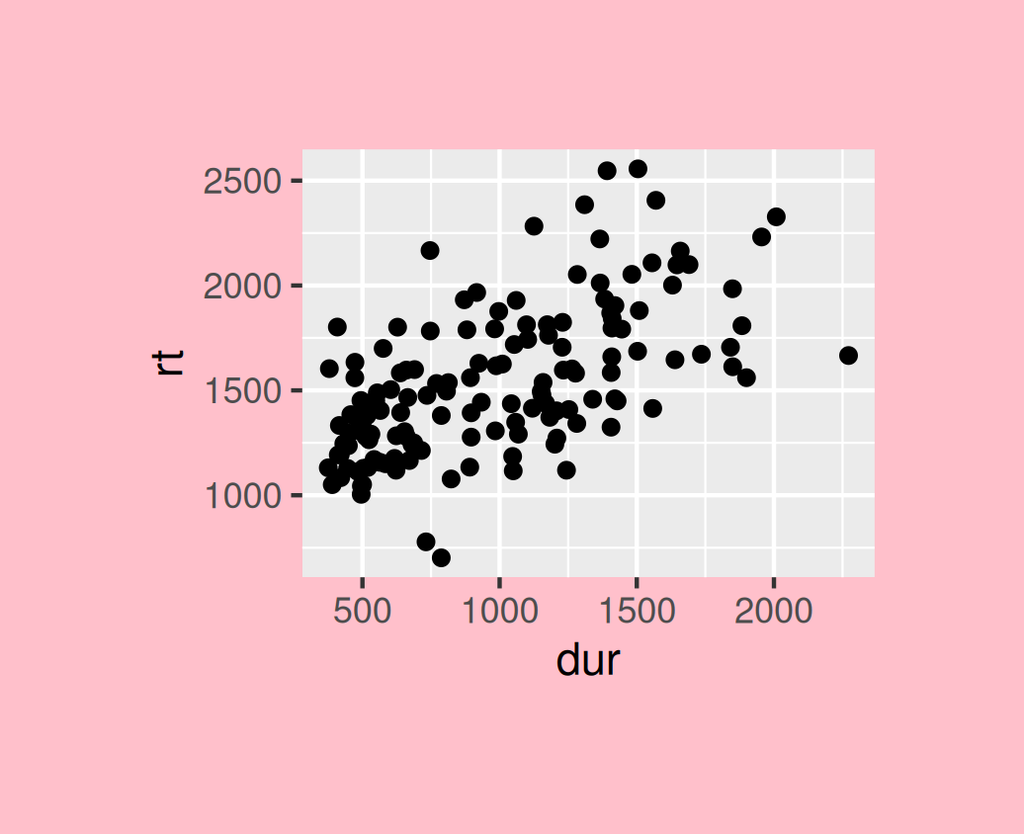

```r
ggplot(d_spellname, aes(y = rt,
    x = dur)) +
  geom_point() +
  theme(plot.background = element_rect(
    fill = "pink"),
  plot.margin = unit(c(2, 2, 2, 2),
                     "cm"))
```

## Title Colour Can Help Or Hinder Readability

- `plot.background`
- `plot.margin`
- `plot.title`
- `plot.subtitle`
- `plot.caption`
- `plot.tag`

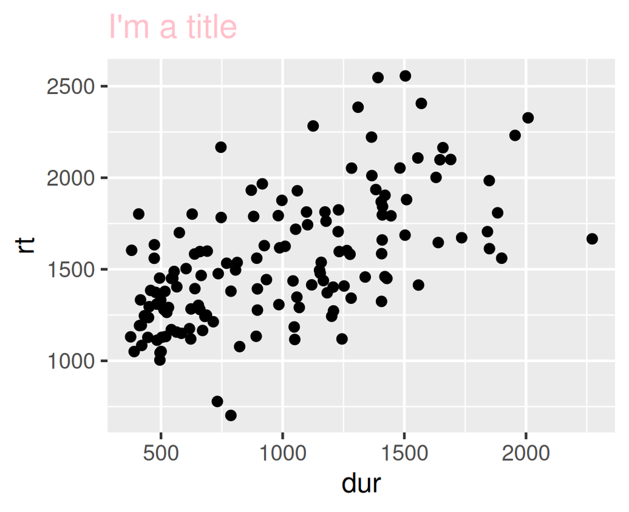

```r
ggplot(d_spellname, aes(y = rt,
    x = dur)) +
  geom_point() +
  labs(title = "I'm a title") +
  theme(plot.title = element_text(
    colour = "pink"))
```

## Caption Text Can Be Styled Separately

- `plot.background`
- `plot.margin`
- `plot.title`
- `plot.subtitle`
- `plot.caption`
- `plot.tag`

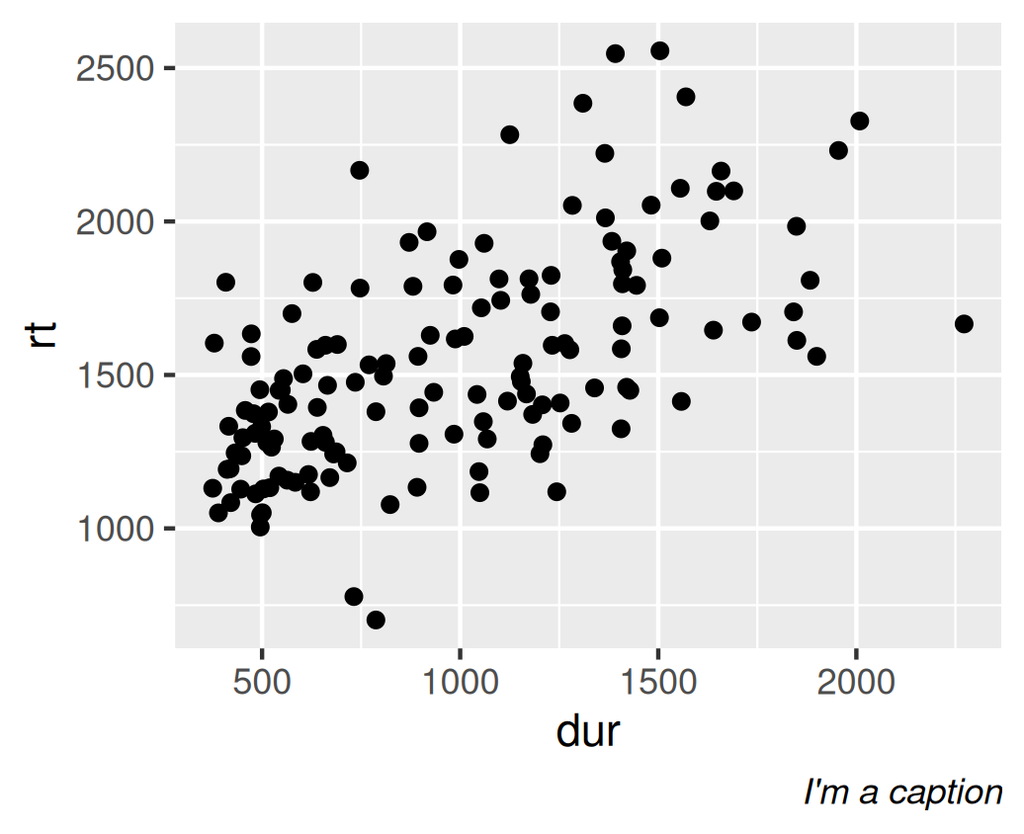

```r
ggplot(d_spellname, aes(y = rt,
    x = dur)) +
  geom_point() +
  labs(caption = "I'm a caption") +
  theme(plot.caption = element_text(
    face = "italic"))
```

## Facet Strips Guide Small Multiples

- `strip.background`
- `strip.placement`
- `strip.text`

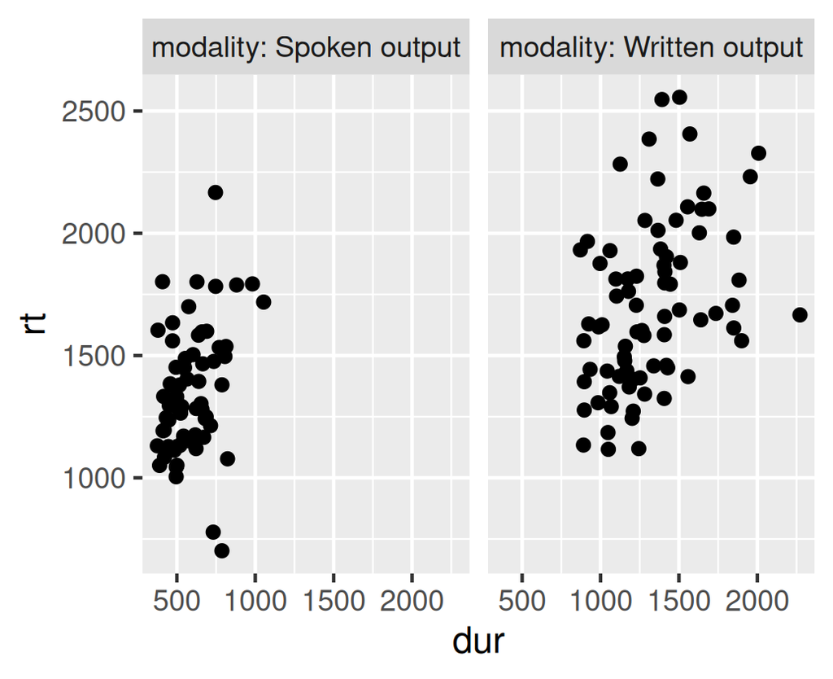

```r
ggplot(d_spellname, aes(y = rt,
    x = dur)) +
  geom_point() +
  facet_grid(~modality,
             labeller = label_both) +
  theme()
```

## Strip Backgrounds Can Add Clutter

- `strip.background`
- `strip.placement`
- `strip.text`

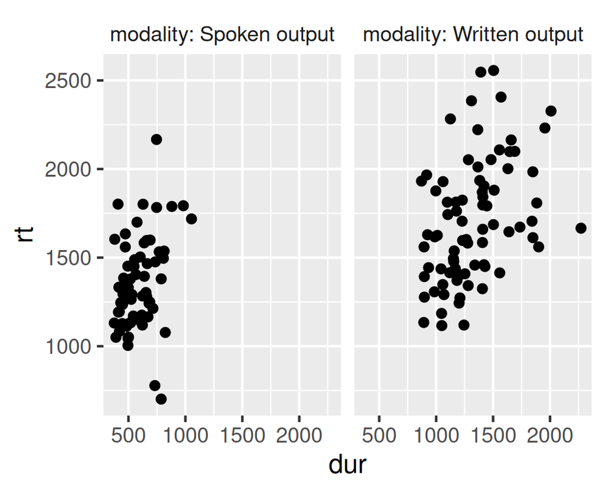

```r
ggplot(d_spellname, aes(y = rt,
    x = dur)) +
  geom_point() +
  facet_grid(~modality,
             labeller = label_both) +
  theme(strip.background =
        element_blank())
```

## Strip Background Colour Changes The Emphasis

- `strip.background`
- `strip.placement`
- `strip.text`

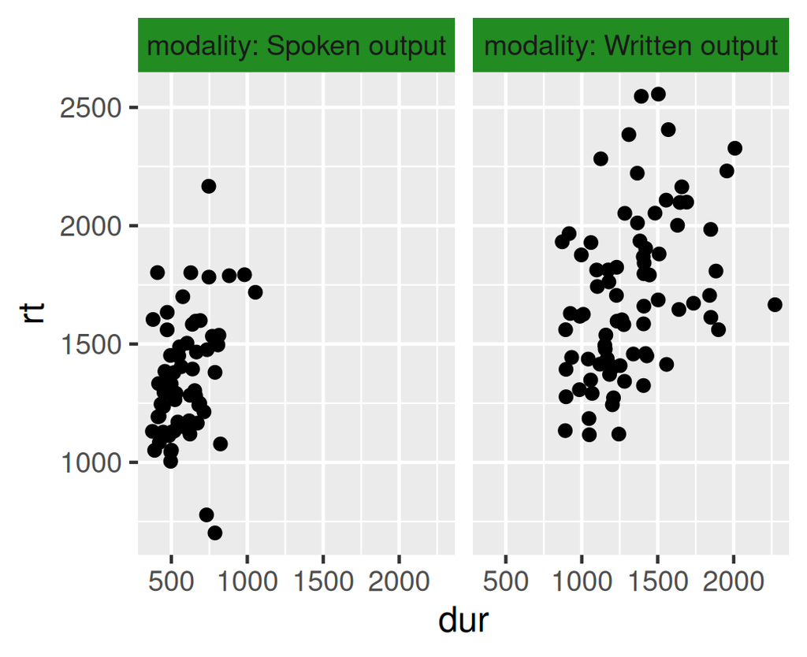

```r
ggplot(d_spellname, aes(y = rt,
    x = dur)) +
  geom_point() +
  facet_grid(~modality,
             labeller = label_both) +
  theme(strip.background = element_rect(
    fill = "forestgreen"))
```

## Strip Text Needs To Stay Readable

- `strip.background`
- `strip.placement`
- `strip.text`

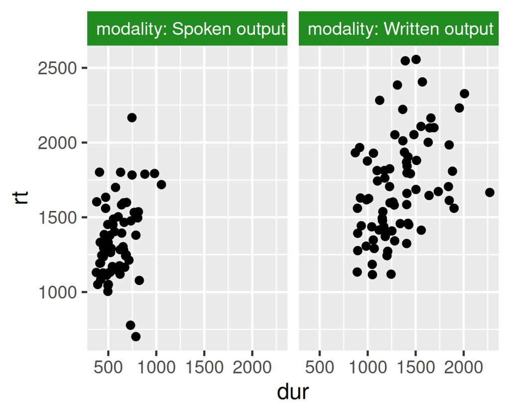

```r
ggplot(d_spellname, aes(y = rt,
    x = dur)) +
  geom_point() +
  facet_grid(~modality,
             labeller = label_both) +
  theme(strip.background = element_rect(fill = "forestgreen"),
        strip.text = element_text(colour = "white", hjust = 0))
```

## Combine Theme Changes Deliberately

- `strip.background`
- `strip.placement`
- `strip.text`

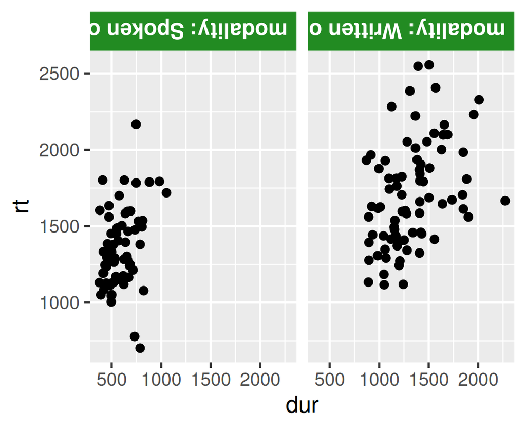

```r
ggplot(d_spellname, aes(y = rt,
    x = dur)) +
  geom_point() +
  facet_grid(~modality,
             labeller = label_both)+
  theme(strip.background = element_rect(fill = "forestgreen"),
        strip.text = element_text(colour = "white", hjust = 0,
            face = "bold", size = 16, angle = 180))
```